# Supervised machine learning (ML) using R

## Summary

The goal is to analyse the [Breast Cancer Wisconsin Data Set](http://archive.ics.uci.edu/ml/datasets/Breast+Cancer+Wisconsin+%28Diagnostic%29) using a variety of [supervised ML methods](https://en.wikipedia.org/wiki/Supervised_learning).

## ML methods

These are the individual methods we will use:

- [Decision Tree Classifier](https://en.wikipedia.org/wiki/Decision_tree_learning)
- [Naive Bayes](https://en.wikipedia.org/wiki/Naive_Bayes_classifier)
- [k-nearest Neighbors](https://en.wikipedia.org/wiki/K-nearest_neighbors_algorithm)
- [Random Forest](https://en.wikipedia.org/wiki/Random_forest)
- [SVM: support-vector machines](https://en.wikipedia.org/wiki/Support-vector_machine)
- [Linear Discriminant Analysis](https://en.wikipedia.org/wiki/Linear_discriminant_analysis)

## Analysis

### R libraries

We need a couple of libraries for the exercises. Let’s load them all upfront:

```r
library(ggplot2)
library(reshape2)
library(caret)
library(rpart.plot)
library(class)
library(randomForest)
library(pander)
library(kernlab)
```

### Data Exploration

Load the data

```r
df=read.table("data.csv.gz", header=T, sep=",")
df$outcome = factor(df$outcome)   # Outcome is a categorical variable
```

Summarize the data set

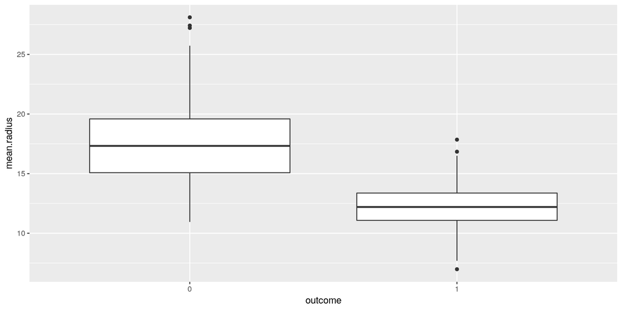

```r
ggplot(data=df, aes(x=outcome, y=mean.radius)) + geom_boxplot(aes(group=outcome))
```

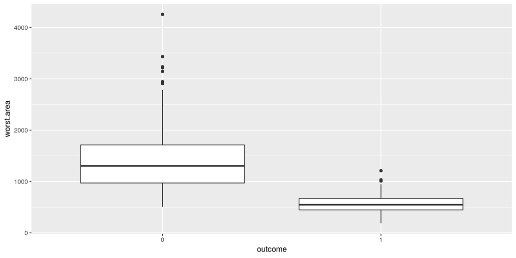

```r
ggplot(data=df, aes(x=outcome, y=worst.area)) + geom_boxplot(aes(group=outcome))
```

Plot all features at once

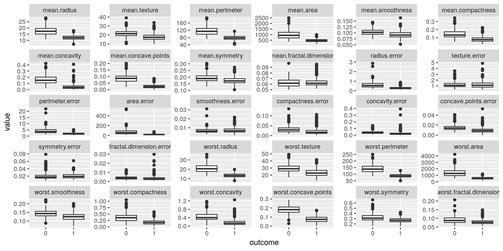

```r
lf = melt(df, id=c("outcome"))
ggplot(data=lf, aes(x=outcome, y=value)) +
    geom_boxplot(aes(group=outcome)) +
    facet_wrap(~variable, scales="free_y")
```

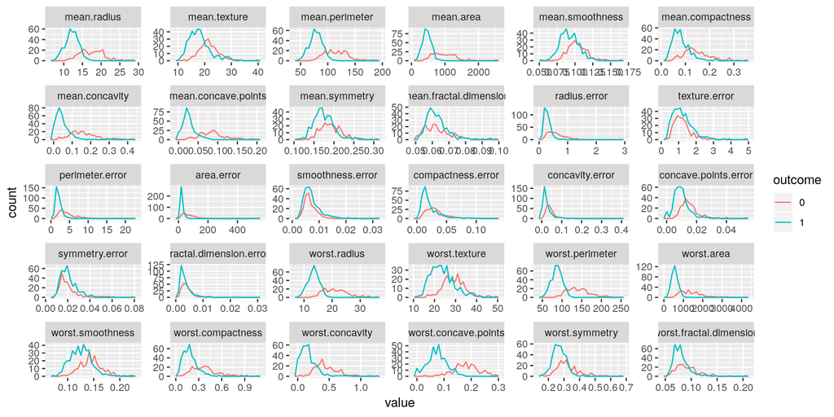

```r
ggplot(data=lf, aes(x=value)) +
    geom_freqpoly(aes(group=outcome, color=outcome), stat="bin", bins=30) +
    facet_wrap(~variable, scales="free")
```

### Splitting Training and Testing data

The dimensions of the data matrix are 31 columns and 569 rows.

```r
print(dim(df))
```

```
## [1] 569  31
```

```r
set.seed(3033)
train = createDataPartition(y = df$outcome, p=0.8, list=F)
training = df[train,]
print(dim(training))
```

```
## [1] 456  31
```

```r
testing = df[-train,]
print(dim(testing))
```

```
## [1] 113  31
```

```r
pander(table(training$outcome), caption="Training outcome distribution")
```

Training outcome distribution

| 0 | 1 |
| --- | --- |
| 170 | 286 |

```r
pander(table(testing$outcome), caption="Testing outcome distribution")
```

Testing outcome distribution

| 0 | 1 |
| --- | --- |
| 42 | 71 |

### Decision Tree Classifier

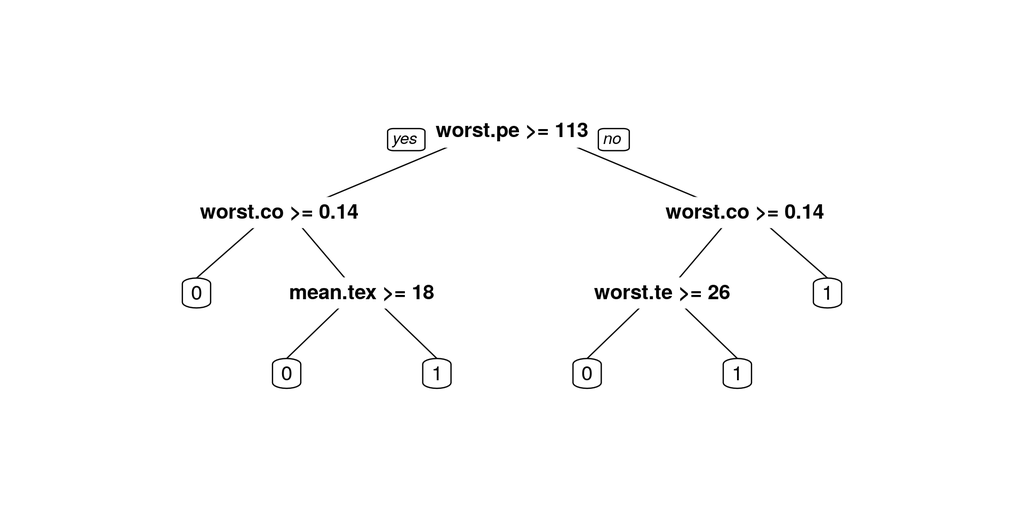

```r
trctrl = trainControl(method="repeatedcv", number=10, repeats=3)
fit = train(outcome ~ ., data=training, method="rpart", parms = list(split="information"), trControl=trctrl, tuneLength=10)
prp(fit$finalModel, tweak=1.2)
```

```r
pred = predict(fit, newdata=testing)
```

Let’s take a look at the [confusion matrix](https://en.wikipedia.org/wiki/Confusion_matrix):

```r
cm <- table(data.frame(prediction=pred, truth=testing$outcome))
pander(cm, caption="Confusion Matrix for Decision Tree")
```

Confusion Matrix for Decision Tree

|  | 0 | 1 |
| --- | --- | --- |
| **0** | 38 | 4 |
| **1** | 4 | 67 |

### Naive Bayes

```r
fit = train(outcome ~ ., data=training, method="naive_bayes", trControl=trctrl, tuneLength=10)
pred = predict(fit, newdata=testing)
cm <- table(data.frame(prediction=pred, truth=testing$outcome))
pander(cm, caption="Confusion Matrix for Naive Bayes")
```

Confusion Matrix for Naive Bayes

|  | 0 | 1 |
| --- | --- | --- |
| **0** | 37 | 2 |
| **1** | 5 | 69 |

### k-nearest Neighbors

```r
fit = train(outcome ~ ., data=training, method="knn", trControl=trctrl, tuneLength=10)
pred = predict(fit, newdata=testing)
cm <- table(data.frame(prediction=pred, truth=testing$outcome))
pander(cm, caption="Confusion Matrix for k-NN")
```

Confusion Matrix for k-NN

|  | 0 | 1 |
| --- | --- | --- |
| **0** | 38 | 3 |
| **1** | 4 | 68 |

### Random Forest

```r
fit = train(outcome ~ ., data=training, method="rf", trControl=trctrl, tuneLength=10)
pred = predict(fit, newdata=testing)
cm <- table(data.frame(prediction=pred, truth=testing$outcome))
pander(cm, caption="Confusion Matrix for Random Forest")
```

Confusion Matrix for Random Forest

|  | 0 | 1 |
| --- | --- | --- |
| **0** | 38 | 1 |
| **1** | 4 | 70 |

### SVM

```r
fit = train(outcome ~ ., data=training, method="svmLinear", trControl=trctrl, tuneLength=10)
pred = predict(fit, newdata=testing)
cm <- table(data.frame(prediction=pred, truth=testing$outcome))
pander(cm, caption="Confusion Matrix for SVM")
```

Confusion Matrix for SVM

|  | 0 | 1 |
| --- | --- | --- |
| **0** | 39 | 1 |
| **1** | 3 | 70 |

### Linear Discriminant Analysis

```r
fit = train(outcome ~ ., data=training, method="lda2", trControl=trctrl, tuneLength=10)
pred = predict(fit, newdata=testing)
cm <- table(data.frame(prediction=pred, truth=testing$outcome))
pander(cm, caption="Confusion Matrix for LDA")
```

Confusion Matrix for LDA

|  | 0 | 1 |
| --- | --- | --- |
| **0** | 38 | 1 |
| **1** | 4 | 70 |

## Questions

A couple of question for yourself to explore the data further.

- What is the true positive rate (sensitivity) for each method?
- What is the true negative rate (specificity) for each method?
- What is the precision (positive predictive value) for each method?
- What is the false discovery rate (FDR) for each method?
- What is the accuracy for each method?